# Formative Exercise 09: Functions

Edit the code chunks below and knit the document. You can pipe your objects to `glimpse()` or `print()` to display them.

## Basic Iteration Functions

### Question 1

Set the vector `v1` equal to the following: 11, 13, 15, 17, 19, …, 99, 101 (use a function; don’t just type all the numbers).

```r
v1 <- seq(11, 101, by = 2) |> print()
```

```
##  [1]  11  13  15  17  19  21  23  25  27  29  31  33  35  37  39  41  43  45  47  49  51  53  55  57  59
## [26]  61  63  65  67  69  71  73  75  77  79  81  83  85  87  89  91  93  95  97  99 101
```

### Question 2

Set the vector `v2` equal to the following: “A” “A” “B” “B” “C” “C” “D” “D” “E” “E” (note the letters are all uppercase).

```r
v2 <- rep(LETTERS[1:5], each = 2) |> print()
```

```
##  [1] "A" "A" "B" "B" "C" "C" "D" "D" "E" "E"
```

### Question 3

Set the vector `v3` equal to the words “dog” 10 times, “cat” 9 times, “fish” 6 times, and “ferret” 1 time.

```r
pets <- c("dog", "cat", "fish", "ferret")
pet_n <- c(10, 9, 6, 1)
v3 <- rep(pets, times = pet_n) |> print()
```

```
##  [1] "dog"    "dog"    "dog"    "dog"    "dog"    "dog"    "dog"    "dog"    "dog"    "dog"    "cat"
## [12] "cat"    "cat"    "cat"    "cat"    "cat"    "cat"    "cat"    "cat"    "fish"   "fish"   "fish"
## [23] "fish"   "fish"   "fish"   "ferret"
```

## map and apply functions

### Question 4a

Use `apply()` or `map()` functions to create a list of 11 vectors of 100 numbers sampled from 11 random normal distributions with means of 0 to 1.0 (in steps of 0.1) and SDs of 1. Assign this list to the object `samples`. Set the seed to `321` before you generate the random numbers to ensure reproducibility.

```r
set.seed(321)
mu <- seq(0, 1, 0.1)
samples <- map(mu, rnorm, n = 100)

# alternatively
samples <- lapply(mu, rnorm, n = 100)
```

### Question 4b

Use `apply()` or `map()` functions to create a vector of the sample means from the list `samples` in the previous question.

```r
sample_means <- map_dbl(samples, mean)

## alternatively

sample_means <- sapply(samples, mean) |> print()
```

```
##  [1] 0.08304484 0.21226580 0.16840128 0.12930317 0.53216771 0.40842952 0.72589166 0.63446436 0.81040369
## [10] 1.02317536 0.91126680
```

## Custom functions

### Question 5a

Write a function called `my_add` that adds two numbers (`x` and `y`) together and returns the results.

```r
my_add <- function(x, y) {
  x+y
}
```

### Question 5b

Create a vector testing your function `my_add`. Every item in the vector should evaluate to `TRUE` if your function is working correctly.

```r
my_add_test <- c(
  my_add(1, 2) == 3,
  my_add(10, 20) == 30,
  my_add(-1, -3) == -4,
  my_add(0.2, 0.334) == 0.534
) |> print()
```

```
## [1] TRUE TRUE TRUE TRUE
```

## Error handling

### Question 6

Copy the function `my_add` above and add an error message that returns “x and y must be numbers” if `x` or `y` are not both numbers.

```r
my_add <- function(x, y) {
  if (!is.numeric(x) | !is.numeric(y)) stop("x and y must be numbers")
  x+y
}
```

## Building up a custom function

### Question 7

Create a tibble called `dat` that contains 20 rows and three columns: `id` (integers 101 through 120), `pre` and `post` (both 20-item vectors of random numbers from a normal distribution with mean = 0 and sd = 1). Set seed to `90210` to ensure reproducible values.

```r
set.seed(90210)

dat <- tibble(
  id = 101:120,
  pre = rnorm(20),
  post = rnorm(20)
) |> print()
```

```
## # A tibble: 20 × 3
##       id     pre   post
##    <int>   <dbl>  <dbl>
##  1   101 -0.444   0.664
##  2   102 -0.515  -1.78
##  3   103  1.18   -1.21
##  4   104  1.57   -1.40
##  5   105  0.0934  1.83
##  6   106  0.165  -1.43
##  7   107 -0.339  -2.17
##  8   108 -0.780  -0.789
##  9   109  0.386   0.172
## 10   110 -1.83   -1.24
## 11   111 -0.544   0.319
## 12   112 -0.138  -1.63
## 13   113  0.296   0.395
## 14   114 -0.434  -1.85
## 15   115 -0.502  -2.53
## 16   116  0.113   0.279
## 17   117 -0.781   0.824
## 18   118  0.916  -0.622
## 19   119  0.179   0.928
## 20   120  0.0141  0.266
```

### Question 8

Run a two-tailed, *paired-samples* t-test comparing `pre` and `post`. (check the help for `t.test`)

```r
t <- t.test(dat$post, dat$pre, paired = TRUE) |> print()
```

```
##
##  Paired t-test
##
## data:  dat$post and dat$pre
## t = -1.5392, df = 19, p-value = 0.1402
## alternative hypothesis: true mean difference is not equal to 0
## 95 percent confidence interval:
##  -1.1299798  0.1722842
## sample estimates:
## mean difference
##      -0.4788478
```

### Question 9

Use `broom::tidy` to save the results of the t-test in question 8 in a table called `stats`.

```r
stats <- t.test(dat$post, dat$pre, paired = TRUE) |>
  broom::tidy() |>
  print()
```

```
## # A tibble: 1 × 8
##   estimate statistic p.value parameter conf.low conf.high method        alternative
##      <dbl>     <dbl>   <dbl>     <dbl>    <dbl>     <dbl> <chr>         <chr>
## 1   -0.479     -1.54   0.140        19    -1.13     0.172 Paired t-test two.sided
```

### Question 10

Create a function called `report_t` that takes a data table as an argument and returns the result of a two-tailed, paired-samples t-test between the columns `pre` and `post` in the following format:

“The mean increase from pre-test to post-test was #.###: t(#) = #.###, p = 0.###, 95% CI = [#.###, #.###].”

Hint: look at the function `paste0()` (simpler) or `sprintf()` (complicated but more powerful).

NB: Make sure all numbers are reported to three decimal places (except degrees of freedom).

```r
report_t <- function(data) {
  stats <- t.test(data$post, data$pre, paired = TRUE) |>
    broom::tidy()

  diff <- pull(stats, estimate) |> round(3)
  t <- pull(stats, statistic) |> round(3)
  p <- pull(stats, p.value) |> round(3)
  df <- pull(stats, parameter)
  ci1 <- pull(stats, conf.low) |> round(3)
  ci2 <- pull(stats, conf.high) |> round(3)

  paste0("The mean increase from pre-test to post-test was ", diff,
         ": t(", df, ") = ", t,
         ", p = ", p,
         ", 95% CI = [", ci1, ", ", ci2, "].")
}
```

```r
# glue works well in a pipeline
# but doesn't format digits as nicely as sprintf (below),
# so we have to round the values before constructing the text
report_t <- function(data) {
  t.test(data$post, data$pre, paired = TRUE) |>
    broom::tidy() |>
    mutate(across(.cols = where(is.numeric),
                  .fns = round,
                  digits = 3)) |>
    mutate(
      text = glue::glue("The mean increase from pre-test to post-test was {estimate}: t({parameter}) = {statistic}, p = {p.value}, 95% CI = [{conf.low}, {conf.high}].")) |>
    pull(text)
}
```

```r
# sprintf() is a complicated function, but can be easier to use in long text strings with a lot of things to replace
# it also formats values with leading or trailing zeroes

report_t <- function(data) {
  stats <- t.test(data$post, data$pre, paired = TRUE) |>
    broom::tidy() |>
    # make sure to round values
    mutate(across(.cols = where(is.numeric),
                  .fns = round,
                  digits = 3))

  sprintf("The mean increase from pre-test to post-test was %.3f: t(%.0f) = %.3f, p = %.3f, 95%% CI = [%.3f, %.3f].",
          pull(stats, estimate),
          pull(stats, parameter),
          pull(stats, statistic),
          pull(stats, p.value),
          pull(stats, conf.low),
          pull(stats, conf.high)
  )
}
```

### Question 11

Use inline R to include the results of `report_t()` on the `dat` data table in a paragraph below.

The mean increase from pre-test to post-test was -0.479: t(19) = -1.539, p = 0.140, 95% CI = [-1.130, 0.172].

## Functions and GLM

### Question 12

Write a function to simulate data with the form.

$Y_i = \beta_0 + \beta_1 X_i + e_i$

The function should take arguments for the number of observations to return (`n`), the intercept (`b0`), the effect (`b1`), the mean and SD of the predictor variable X (`X_mu` and `X_sd`), and the SD of the residual error (`err_sd`). The function should return a tibble with `n` rows and the columns `id`, `X` and `Y`.

```r
sim_lm_data <- function(n = 100, b0 = 0, b1 = 0,
                        X_mu = 0, X_sd = 1, err_sd = 1) {
  tibble(
    id = 1:n,
    X = rnorm(n, X_mu, X_sd),
    err = rnorm(n, 0, err_sd),
    Y = b0 + b1*X + err
  ) |>
    select(id, X, Y)
}

dat12 <- sim_lm_data(n = 10) |> print() # do not edit
```

```
## # A tibble: 10 × 3
##       id      X      Y
##    <int>  <dbl>  <dbl>
##  1     1 -0.652 -0.596
##  2     2 -0.203 -2.74
##  3     3  1.47   0.925
##  4     4  0.167  1.97
##  5     5  1.05   0.430
##  6     6 -1.54   2.87
##  7     7 -0.844  0.863
##  8     8  1.28  -1.53
##  9     9  0.228  3.08
## 10    10 -0.139 -1.03
```

### Question 13

Use the function from Question 12 to generate a data table with 10000 subjects, an intercept of 80, an effect of X of 0.5, where X has a mean of 0 and SD of 1, and residual error SD of 2.

```r
dat13 <- sim_lm_data(n = 10000, b0 = 80, b1 = 0.5,
                   X_mu = 0, X_sd = 1, err_sd = 2)
```

Analyse the data with `lm()`. Find where the analysis summary estimates the values of `b0` and `b1`. What happens if you change the simulation values?

```r
mod13 <- lm(Y ~ X, data = dat13)

summary(mod13) # print summary
```

```
##
## Call:
## lm(formula = Y ~ X, data = dat13)
##
## Residuals:
##     Min      1Q  Median      3Q     Max
## -7.0142 -1.3482 -0.0096  1.3461  7.6196
##
## Coefficients:
##             Estimate Std. Error t value Pr(>|t|)
## (Intercept) 80.02120    0.01995 4011.41   <2e-16 ***
## X            0.51326    0.02001   25.65   <2e-16 ***
## ---
## Signif. codes:  0 '***' 0.001 '**' 0.01 '*' 0.05 '.' 0.1 ' ' 1
##
## Residual standard error: 1.995 on 9998 degrees of freedom
## Multiple R-squared:  0.06174,    Adjusted R-squared:  0.06165
## F-statistic: 657.9 on 1 and 9998 DF,  p-value: < 2.2e-16
```

### Question 14

Hint: use `broom::tidy()` to get the p-value for the effect of X.

```r
# ... lets you include any arguments to send to sim_lm_data()
sim_lm_power <- function(...) {
  dat <- sim_lm_data(...)
  lm(Y~X, dat) |>
    broom::tidy() |>
    filter(term == "X") |>
    pull(p.value)
}

p_values <- replicate(1000, sim_lm_power(n = 50, b0 = 80, b1 = 0.5, X_mu = 0, X_sd = 1, err_sd = 2))

power <- mean(p_values < .05)

power # print the value
```

```
## [1] 0.424
```

### Question 15

Calculate power (i.e., the false positive rate) for the effect of X on Y in a design with 50 subjects where there is no effect and alpha is 0.05.

```r
p_values <- replicate(1000, sim_lm_power(n = 50, b1 = 0))

false_pos <- mean(p_values < .05)

false_pos # print the value
```

```
## [1] 0.056
```

Make a histogram of the p-values from the simulation above. Use geom_histogram with `binwidth=0.05` and `boundary=0`. What kind of distribution is this?

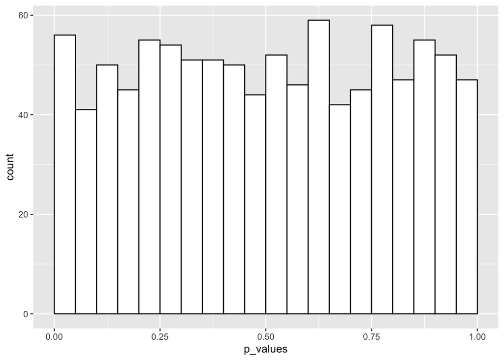

```r
ggplot(mapping = aes(x = p_values)) +
  geom_histogram(color = "black", fill = "white", binwidth = .05, boundary = 0)
```